# Разработка моделей машиного обучения с целью предсказания уровня удовлетворённости сотрудника и предсказания увольнения сотрудника из компании

# Описание проекта

Машинное обучение может быть ценным инструментом для HR-аналитиков различных компаний. Используя машинное обучение, HR-специалисты могут быстрее и точнее отвечать на вопросы бизнеса, оптимизировать управление персоналом и увеличить рентабельность бизнеса.

HR-аналитики одной известной компании помогают бизнесу оптимизировать управление персоналом: бизнес предоставляет данные, а аналитики предлагают, как избежать финансовых потерь и оттока сотрудников. В этом HR-аналитикам пригодится машинное обучение, с помощью которого получится быстрее и точнее отвечать на вопросы бизнеса.

Компания предоставила данные с характеристиками сотрудников компании. Среди них — уровень удовлетворённости сотрудника работой в компании. Эту информацию получили из форм обратной связи: сотрудники заполняют тест-опросник, и по его результатам рассчитывается доля их удовлетворённости от 0 до 1, где 0 — совершенно неудовлетворён, 1 — полностью удовлетворён.

Собирать данные такими опросниками не так легко: компания большая, и всех сотрудников надо сначала оповестить об опросе, а затем проследить, что все его прошли.

# Задачи проекта

**Первая задача** — построить модель, которая сможет предсказать уровень удовлетворённости сотрудника на основе данных заказчика.

Почему бизнесу это важно: удовлетворённость работой напрямую влияет на отток сотрудников. А предсказание оттока — одна из важнейших задач HR-аналитиков. Внезапные увольнения несут в себе риски для компании, особенно если уходит важный сотрудник.

**Вторая задача** — построить модель, которая сможет на основе данных заказчика предсказать то, что сотрудник уволится из компании.

# Описание данных

Заказчик предоставил данные с признаками:

- `id` — уникальный идентификатор сотрудника;
- `dept` — отдел, в котором работает сотрудник;
- `level` — уровень занимаемой должности;
- `workload` — уровень загруженности сотрудника;
- `employment_years` — длительность работы в компании (в годах);
- `last_year_promo` — показывает, было ли повышение за последний год;
- `last_year_violations` — показывает, нарушал ли сотрудник трудовой договор за последний год;
- `supervisor_evaluation` — оценка качества работы сотрудника, которую дал руководитель;
- `salary` — ежемесячная зарплата сотрудника;
- `job_satisfaction_rate` — уровень удовлетворённости сотрудника работой в компании, целевой признак;
- `quit` — увольнение сотрудника из компании.

# План работы для первой задачи

**Шаг 1. Загрузка данных**

Загрузить файлы с данными:

- Тренировочная выборка: `train_job_satisfaction_rate.csv`
- Входные признаки тестовой выборки: `test_features.csv`
- Целевой признак тестовой выборки: `test_target_job_satisfaction_rate.csv`

**Шаг 2. Предобработка данных**

Изучить данные и сделать выводы. При необходимости выполнить предобработку. Если есть пропуски, заполнить их в пайплайне.

**Шаг 3. Исследовательский анализ данных**

Исследовать все признаки и сделать выводы о том, как их нужно подготовить.

**Шаг 4. Подготовка данных**

Подготовку признаков выполнить в пайплайне, дополнив пайплайн шага предобработки. При кодировании учитывать особенности признаков и моделей и использовать как минимум два кодировщика.

**Шаг 5. Обучение моделей**

Обучить как минимум две модели. Взять одну линейную модель, а в качестве второй — дерево решений. Подобрать гиперпараметры как минимум для одной модели с помощью одного из известных инструментов. Выберать лучшую модель и проверить её качество. Выбор делать на основе новой метрики — SMAPE (англ. symmetric mean absolute percentage error, «симметричное среднее абсолютное процентное отклонение»).

**Шаг 6. Оформление выводов**

Сделать промежуточные выводы о том, какая модель справилась лучше и почему.

# План работы для второй задачи

**Шаг 1. Загрузка данных**

Загрузить файлы с данными:

- Тренировочная выборка: `train_quit.csv`
- Входные признаки тестовой выборки: `test_features.csv`
- Целевой признак тестовой выборки: `test_target_quit.csv`

**Шаг 2. Предобработка данных**

Изучить данные и сделать выводы. При необходимости выполнить предобработку. Если есть пропуски, заполнить их в пайплайне.

**Шаг 3. Исследовательский анализ данных**

1. Провести исследовательский анализ данных.
2. Составить портрет «уволившегося сотрудника». Например, можно узнать, в каком отделе с большей вероятностью работает уволившийся сотрудник и какой у него уровень загруженности. Также можно сравнить среднее значение зарплаты ушедших сотрудников с теми, кто остался в компании.
3. Аналитики утверждают, что уровень удовлетворённости сотрудника работой в компании влияет на то, уволится ли сотрудник. Проверить это утверждение: визуализировать и сравнить распределения признака `job_satisfaction_rate` для ушедших и оставшихся сотрудников. Использовать данные с обоими целевыми признаками тестовой выборки.

**Шаг 4. Подготовка данных**

Допустим, `job_satisfaction_rate` и `quit` действительно связаны и мы получили необходимое значение метрики в первой задаче. Тогда добавим `job_satisfaction_rate`, предсказанный лучшей моделью первой задачи, к входным признакам второй задачи.

**Шаг 5. Подготовка данных**

Подготовить признаки так же, как и в первой задаче: выполнить подготовку в пайплайне, дополнив пайплайн предобработки. При кодировании учитывать особенности признаков и моделей и использовать как минимум два кодировщика.

**Шаг 6. Обучение моделей**

Обучить как минимум три модели. Как минимум для двух из них подобрать гиперпараметры. Проверить качество лучшей модели.

Метрика оценки качества в этой задаче — ROC-AUC. Критерий успеха: ROC-AUC ≥ 0.91 на тестовой выборке. (Отбор признаков часто помогает улучшить метрику.)

**Шаг 7. Выводы**

Сделать промежуточные выводы о том, какая модель справилась лучше и почему.

**Общий вывод**

Сформулировать общий вывод:

- описать задачу;
- описать все этапы работы;
- добавить выводы и дополнительные предложения для бизнеса.

# Задача №1 - Предсказание уровня удовлетворённости сотрудника

## Задача №1. Загрузка данных

На данном шаге нам необходимо загрузить необходимые библиотеки, загрузить и ознакомится с данными.

### Импортируем необходимые библиотеки

```python
!pip install -q -U scikit-learn
!pip install -q shap
!pip install -q phik
import pandas as pd
import numpy as np
import seaborn as sns
import matplotlib.pyplot as plt
import scipy.stats as st
import sklearn
import shap
import phik

import warnings
warnings.filterwarnings('ignore')

# Задаем константы
RANDOM_STATE = 42
TEST_SIZE = 0.5

# импортируем класс RandomizedSearchCV
from sklearn.model_selection import RandomizedSearchCV

# загружаем нужные модели
from sklearn.linear_model import LogisticRegression, LinearRegression, Ridge
from sklearn.neighbors import KNeighborsClassifier
from sklearn.tree import DecisionTreeClassifier, DecisionTreeRegressor
from sklearn.dummy import DummyRegressor, DummyClassifier
from sklearn.svm import SVC

# загружаем классы для подготовки данных
from sklearn.preprocessing import (
    OneHotEncoder,
    OrdinalEncoder,
    StandardScaler,
    MinMaxScaler,
    RobustScaler,
    QuantileTransformer,
    LabelEncoder)

# загружаем необходимые инструменты
from sklearn.pipeline import Pipeline
from sklearn.compose import ColumnTransformer

# загружаем класс для работы с пропусками
from sklearn.impute import SimpleImputer

# загружаем инструмент для автоподбора гиперпараметров
from sklearn.model_selection import GridSearchCV

# импортируем функции для работы с метриками
from sklearn.metrics import (roc_auc_score, make_scorer)
```

### Загрузим данные в датафреймы pandas.

```python
try:
    train_job = pd.read_csv('train_job_satisfaction_rate.csv', decimal=",")
    test_features = pd.read_csv('test_features.csv', decimal=",")
    test_target_job = pd.read_csv('test_target_job_satisfaction_rate.csv', decimal=",")
except:
    train_job = pd.read_csv('https://code.s3.yandex.net/datasets/train_job_satisfaction_rate.csv', encoding='utf8', decimal=",")
    test_features = pd.read_csv('https://code.s3.yandex.net/datasets/test_features.csv', encoding='utf8', decimal=",")
    test_target_job = pd.read_csv('https://code.s3.yandex.net/datasets/test_target_job_satisfaction_rate.csv', encoding='utf8', decimal=",")
```

```python
train_job.head(3)
```

|  | id | dept | level | workload | employment_years | last_year_promo | last_year_violations | supervisor_evaluation | salary | job_satisfaction_rate |
| --- | --- | --- | --- | --- | --- | --- | --- | --- | --- | --- |
| 0 | 155278 | sales | junior | medium | 2 | no | no | 1 | 24000 | 0.58 |
| 1 | 653870 | hr | junior | high | 2 | no | no | 5 | 38400 | 0.76 |
| 2 | 184592 | sales | junior | low | 1 | no | no | 2 | 12000 | 0.11 |

```python
train_job.info()
```

```
<class 'pandas.core.frame.DataFrame'>
RangeIndex: 4000 entries, 0 to 3999
Data columns (total 10 columns):
 #   Column                 Non-Null Count  Dtype
---  ------                 --------------  -----
 0   id                     4000 non-null   int64
 1   dept                   3994 non-null   object
 2   level                  3996 non-null   object
 3   workload               4000 non-null   object
 4   employment_years       4000 non-null   int64
 5   last_year_promo        4000 non-null   object
 6   last_year_violations   4000 non-null   object
 7   supervisor_evaluation  4000 non-null   int64
 8   salary                 4000 non-null   int64
 9   job_satisfaction_rate  4000 non-null   object
dtypes: int64(4), object(6)
memory usage: 312.6+ KB
```

```python
test_features.head(3)
```

|  | id | dept | level | workload | employment_years | last_year_promo | last_year_violations | supervisor_evaluation | salary |
| --- | --- | --- | --- | --- | --- | --- | --- | --- | --- |
| 0 | 485046 | marketing | junior | medium | 2 | no | no | 5 | 28800 |
| 1 | 686555 | hr | junior | medium | 1 | no | no | 4 | 30000 |
| 2 | 467458 | sales | middle | low | 5 | no | no | 4 | 19200 |

```python
test_features.info()
```

```
<class 'pandas.core.frame.DataFrame'>
RangeIndex: 2000 entries, 0 to 1999
Data columns (total 9 columns):
 #   Column                 Non-Null Count  Dtype
---  ------                 --------------  -----
 0   id                     2000 non-null   int64
 1   dept                   1998 non-null   object
 2   level                  1999 non-null   object
 3   workload               2000 non-null   object
 4   employment_years       2000 non-null   int64
 5   last_year_promo        2000 non-null   object
 6   last_year_violations   2000 non-null   object
 7   supervisor_evaluation  2000 non-null   int64
 8   salary                 2000 non-null   int64
dtypes: int64(4), object(5)
memory usage: 140.8+ KB
```

```python
test_target_job.head(3)
```

|  | id | job_satisfaction_rate |
| --- | --- | --- |
| 0 | 130604 | 0.74 |
| 1 | 825977 | 0.75 |
| 2 | 418490 | 0.6 |

```python
test_target_job.info()
```

```
<class 'pandas.core.frame.DataFrame'>
RangeIndex: 2000 entries, 0 to 1999
Data columns (total 2 columns):
 #   Column                 Non-Null Count  Dtype
---  ------                 --------------  -----
 0   id                     2000 non-null   int64
 1   job_satisfaction_rate  2000 non-null   object
dtypes: int64(1), object(1)
memory usage: 31.4+ KB
```

**Выводы по загрузке и изучению данных:**

По первичной информации замечены неправильные типы данных, пропуски в данных. Данные в таблицах соответствуют описанию.

## Задача №1. Предобработка данных

На данном шаге проверим данные на наличие пропусков и дубликатов. Узнаем, корректны ли типы данных у каждого признака. При необходимости устраним проблемы с данными. Пропуски в данных заполним в пайплайне.

### Проверим данные на наличие неявных дубликатов и ошибок

```python
train_job['dept'].unique()
```

```
array(['sales', 'hr', 'technology', 'purchasing', 'marketing', nan],
      dtype=object)
```

```python
train_job['level'].unique()
```

```
array(['junior', 'middle', 'sinior', nan], dtype=object)
```

```python
train_job.loc[train_job['level']== 'sinior', 'level'] = 'senior'
```

```python
train_job['workload'].unique()
```

```
array(['medium', 'high', 'low'], dtype=object)
```

```python
train_job['last_year_promo'].unique()
```

```
array(['no', 'yes'], dtype=object)
```

```python
train_job['last_year_violations'].unique()
```

```
array(['no', 'yes'], dtype=object)
```

```python
train_job['supervisor_evaluation'].unique()
```

```
array([1, 5, 2, 3, 4], dtype=int64)
```

Обнаружены пропуски в датасете `train_job` в столбцах `dept`, `level`. Их мы заполним в пайплайне.

```python
test_features['dept'].unique()
```

```
array(['marketing', 'hr', 'sales', 'purchasing', 'technology', nan, ' '],
      dtype=object)
```

```python
test_features.loc[test_features['dept']== ' ', 'dept'] = np.nan
```

```python
test_features['level'].unique()
```

```
array(['junior', 'middle', 'sinior', nan], dtype=object)
```

```python
test_features.loc[test_features['level']== 'sinior', 'level'] = 'senior'
```

```python
test_features['workload'].unique()
```

```
array(['medium', 'low', 'high', ' '], dtype=object)
```

```python
test_features.loc[test_features['workload']== ' ', 'workload'] = np.nan
```

```python
test_features['last_year_promo'].unique()
```

```
array(['no', 'yes'], dtype=object)
```

```python
test_features['last_year_violations'].unique()
```

```
array(['no', 'yes'], dtype=object)
```

```python
test_features['supervisor_evaluation'].unique()
```

```
array([5, 4, 3, 1, 2], dtype=int64)
```

Обнаружены пропуски в датасете `test_features` в столбцах `dept`, `level`. Их мы заполним в пайплайне. Обнаружена и исправлена ошибка в слове senior.

### Проверим данные на наличие явных дубликатов

```python
print('Количество явных дубликатов в датасете train_job:', train_job.duplicated().sum())
print('Количество явных дубликатов в датасете test_features:', test_features.duplicated().sum())
print('Количество явных дубликатов в датасете test_target_job:', test_target_job.duplicated().sum())
```

```
Количество явных дубликатов в датасете train_job: 0
Количество явных дубликатов в датасете test_features: 0
Количество явных дубликатов в датасете test_target_job: 0
```

### Преобразуем данные в нужные типы

```python
train_job['job_satisfaction_rate'] = train_job['job_satisfaction_rate'].astype('float64')
```

```python
test_target_job['job_satisfaction_rate'] = test_target_job['job_satisfaction_rate'].astype('float64')
```

### Выводы по предобработке данных

По итогам предобработке данных:

- проверили пропуски в данных;
- проверили данные на явные и неявные дубликаты;
- преобразовали данные к правильному типу. Данные с плавающей точкой типа object были заменены на данные с плавающей точкой типа float64.

## Задача №1. Исследовательский анализ данных

На данном шаге необходимо провести исследовательский анализ данных по каждому датасету и сделать выводы о том, как их нужно подготовить.

### Проведем статистический анализ признаков

```python
train_job.describe()
```

|  | id | employment_years | supervisor_evaluation | salary | job_satisfaction_rate |
| --- | --- | --- | --- | --- | --- |
| count | 4000.000000 | 4000.000000 | 4000.000000 | 4000.000000 | 4000.000000 |
| mean | 544957.621000 | 3.718500 | 3.476500 | 33926.700000 | 0.533995 |
| std | 257883.104622 | 2.542513 | 1.008812 | 14900.703838 | 0.225327 |
| min | 100954.000000 | 1.000000 | 1.000000 | 12000.000000 | 0.030000 |
| 25% | 322836.750000 | 2.000000 | 3.000000 | 22800.000000 | 0.360000 |
| 50% | 534082.500000 | 3.000000 | 4.000000 | 30000.000000 | 0.560000 |
| 75% | 771446.000000 | 6.000000 | 4.000000 | 43200.000000 | 0.710000 |
| max | 999521.000000 | 10.000000 | 5.000000 | 98400.000000 | 1.000000 |

По анализу таблицы описательной статистики признаков датасета `train_job` выбросы и аномалии не наблюдаются.

```python
test_features.describe()
```

|  | id | employment_years | supervisor_evaluation | salary |
| --- | --- | --- | --- | --- |
| count | 2000.000000 | 2000.000000 | 2000.000000 | 2000.000000 |
| mean | 552765.213500 | 3.666500 | 3.526500 | 34066.800000 |
| std | 253851.326129 | 2.537222 | 0.996892 | 15398.436729 |
| min | 100298.000000 | 1.000000 | 1.000000 | 12000.000000 |
| 25% | 339052.000000 | 1.000000 | 3.000000 | 22800.000000 |
| 50% | 550793.000000 | 3.000000 | 4.000000 | 30000.000000 |
| 75% | 765763.750000 | 6.000000 | 4.000000 | 43200.000000 |
| max | 999029.000000 | 10.000000 | 5.000000 | 96000.000000 |

По анализу таблицы описательной статистики признаков датасета `test_features` выбросы и аномалии не наблюдаются.

```python
test_target_job.describe()
```

|  | id | job_satisfaction_rate |
| --- | --- | --- |
| count | 2000.000000 | 2000.00000 |
| mean | 552765.213500 | 0.54878 |
| std | 253851.326129 | 0.22011 |
| min | 100298.000000 | 0.03000 |
| 25% | 339052.000000 | 0.38000 |
| 50% | 550793.000000 | 0.58000 |
| 75% | 765763.750000 | 0.72000 |
| max | 999029.000000 | 1.00000 |

По анализу таблицы описательной статистики признаков датасета `test_target_job` выбросы и аномалии не наблюдаются.

### Построим графики для каждого признака датасета `train_job`

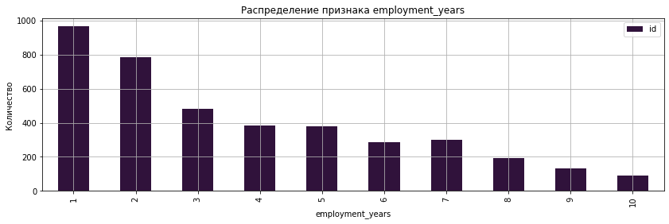

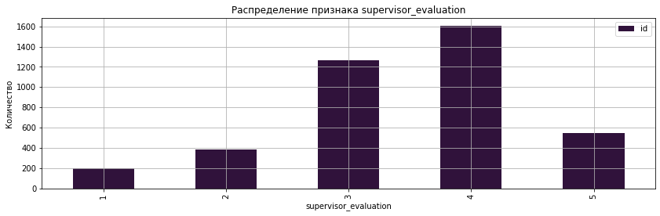

```python
plt.rcParams.update({'font.size': 10})
for i in train_job[['employment_years', 'supervisor_evaluation']]:
    train_job.pivot_table(index=i,
                         values='id',
                         aggfunc='count').plot(kind='bar',
                                               grid=True,
                                               title= f'Распределение признака {i}',
                                               colormap="turbo", figsize=(14,4));
    plt.ylabel('Количество')
    plt.show()
```

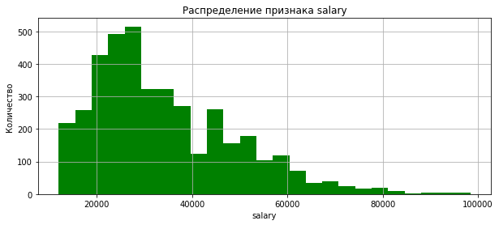

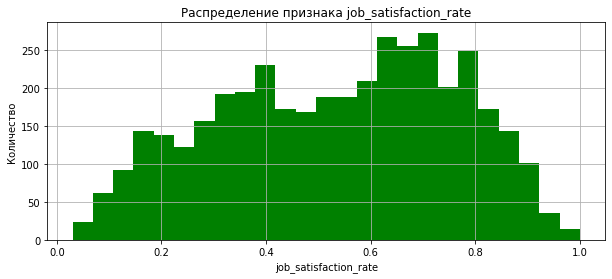

```python
for i in train_job[['salary', 'job_satisfaction_rate']]:
    train_job[i].plot(kind='hist', grid=True, title= f'Распределение признака {i}', bins=25, color='green', figsize=(10,4));
    plt.xlabel(i)
    plt.ylabel('Количество')
    plt.show()
```

Также построим график "ящики с усами", который покажет выбросы и основные статистики данных (квартили)

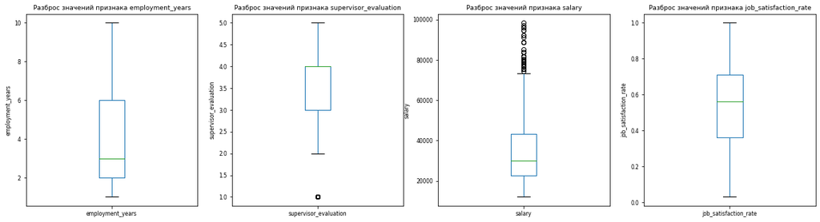

```python
plt.rcParams.update({'font.size': 7.5})
fig, axes = plt.subplots(nrows=1, ncols=4, figsize=(20,5))
axes[0].set_title('Разброс значений признака employment_years')
axes[0].set_ylabel('employment_years')
train_job['employment_years'].plot(kind='box', ax=axes[0])

axes[1].set_title('Разброс значений признака supervisor_evaluation')
axes[1].set_ylabel('supervisor_evaluation')
train_job['supervisor_evaluation'].plot(kind='box', ax=axes[1])

axes[2].set_title('Разброс значений признака salary')
axes[2].set_ylabel('salary')
train_job['salary'].plot(kind='box', ax=axes[2])

axes[3].set_title('Разброс значений признака job_satisfaction_rate')
axes[3].set_ylabel('job_satisfaction_rate')
train_job['job_satisfaction_rate'].plot(kind='box', ax=axes[3])
plt.show();
```

Разберемся с признаком `salary`(ежемесячная зарплата сотрудника).

На графике "ящик с усами" заметны выбросы в большую сторону, начиная с 72000. Проверим, какие уровни занимаемой должности имееют такую зараплатную плату и можно ли это считать выбросами.

```python
train_job_salary = train_job.query('salary>72000')
print(train_job_salary.shape)
#train_job_salary.head(3)
```

```
(66, 10)
```

Ежемесячную зарплату свыше 72000 имеют 66 сотрудников. Проверим далее сколько сотрудников имеют зарплату свыше 72000 и при этом имеет уровень senior. Если количество совпадает, значит, действительно, выбросами это считать не целесообразно.

```python
train_job_salary.query('salary>=72000 & level =="senior"').shape
```

```
(66, 10)
```

Зарпату свыше 72000 имеют сотрудники с уровнем занимаемой должности senior, и, в основном, уровнем загруженности сотрудника high. С учетом этого, не будем считать это выбросами.

**Выводы по графикам количественных признаков:**

- По графикам можно сказать, что признаки распределены не равномерно, имеются выбросы.

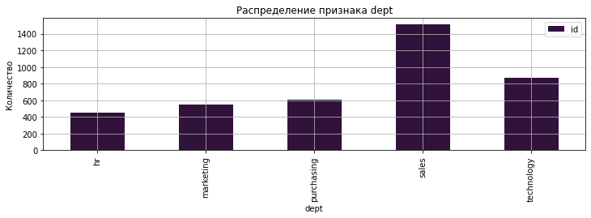

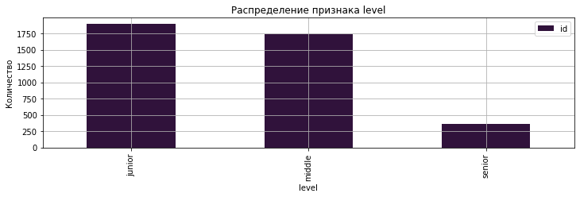

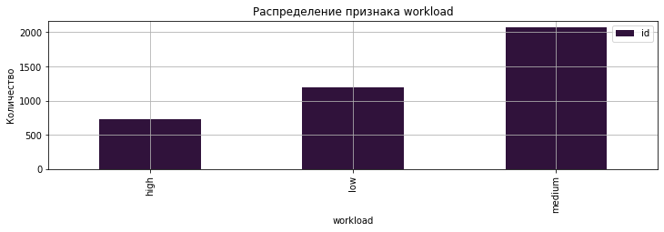

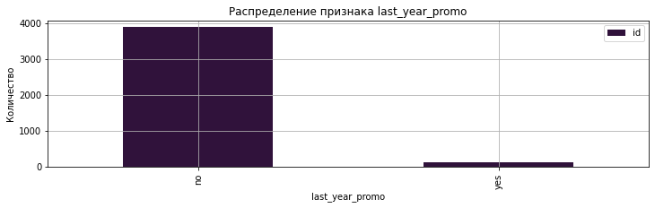

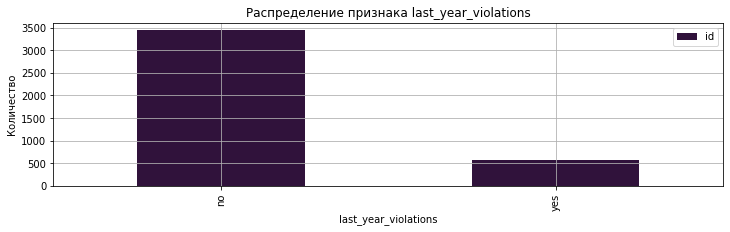

```python
plt.rcParams.update({'font.size': 10})
for i in train_job[['dept', 'level', 'workload', 'last_year_promo', 'last_year_violations']]:
    train_job.pivot_table(index=i,
                         values='id',
                         aggfunc='count').plot(kind='bar',
                                               grid=True,
                                               title= f'Распределение признака {i}',
                                               colormap="turbo", figsize=(12,3));
    plt.ylabel('Количество')
    plt.show()
```

**Выводы по графикам качественных признаков:**

- По распределению признака "dept", можно сказать, что больше всего сотрудников работают в отделе sales.
- По распределению признака "level", можно сказать, что больше всего сотрудников имеют уровень занимаемой должности junior.
- По распределению признака "workload", можно сказать, что больше всего сотрудников имеют уровень загруженности medium.
- По распределению признака "last_year_promo", можно сказать, что чаще сотрудникам не повышали заработную плату за последний год.
- По распределению признака "last_year_violations", можно сказать, что чаще сотрудники не нарушали трудовой договор за последний год.
- По распределению признака "supervisor_evaluation", можно сказать, что чаще сотрудники получают оценку качества от руководителя 4.

### Построим графики для каждого признака датасета `test_features`

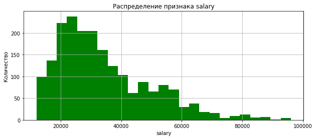

```python
test_features['salary'].plot(kind='hist', grid=True, title= 'Распределение признака salary', bins=25, color='green', figsize=(10,4));
plt.xlabel('salary')
plt.ylabel('Количество')
plt.show()
```

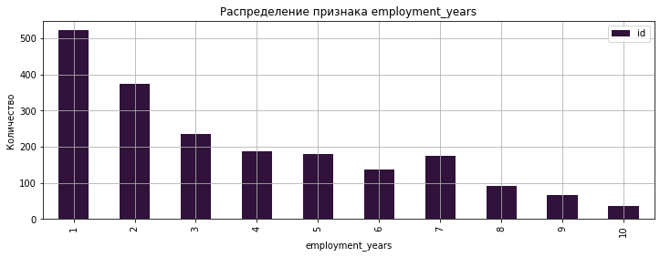

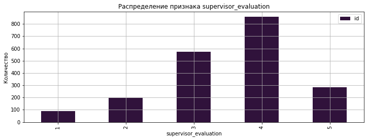

```python
plt.rcParams.update({'font.size': 10})
for i in test_features[['employment_years', 'supervisor_evaluation']]:
    test_features.pivot_table(index=i,
                         values='id',
                         aggfunc='count').plot(kind='bar',
                                               grid=True,
                                               title= f'Распределение признака {i}',
                                               colormap="turbo", figsize=(12,4));
    plt.ylabel('Количество')
    plt.show()
```

Также построим график "ящики с усами", который покажет выбросы и основные статистики данных (квартили)

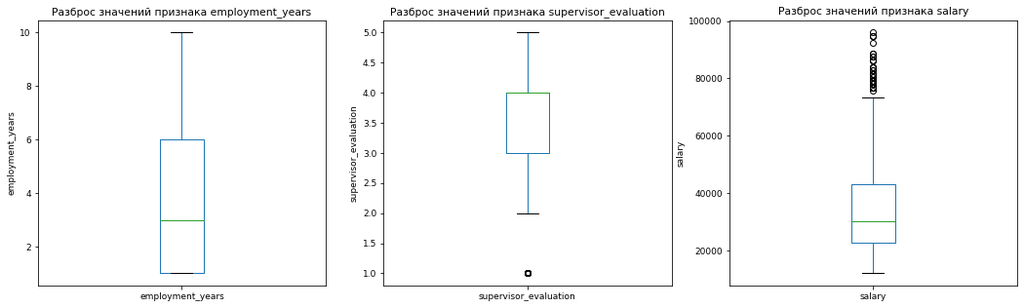

```python
plt.rcParams.update({'font.size': 9})
fig, axes = plt.subplots(nrows=1, ncols=3, figsize=(18,5))
axes[0].set_title('Разброс значений признака employment_years')
axes[0].set_ylabel('employment_years')
test_features['employment_years'].plot(kind='box', ax=axes[0])

axes[1].set_title('Разброс значений признака supervisor_evaluation')
axes[1].set_ylabel('supervisor_evaluation')
test_features['supervisor_evaluation'].plot(kind='box', ax=axes[1])

axes[2].set_title('Разброс значений признака salary')
axes[2].set_ylabel('salary')
test_features['salary'].plot(kind='box', ax=axes[2])
plt.show();
```

**Выводы по графикам количественных признаков:**

- По графикам можно сказать, что признаки распределены не равномерно, имеются выбросы.

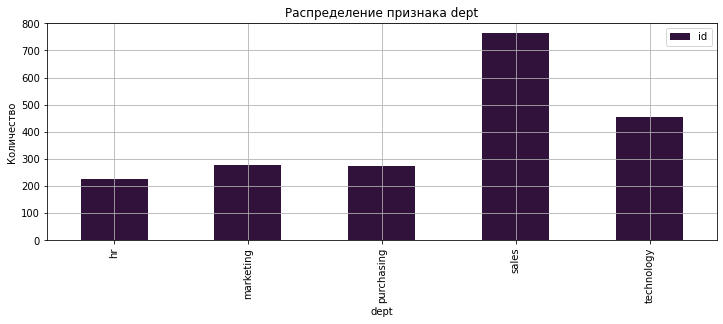

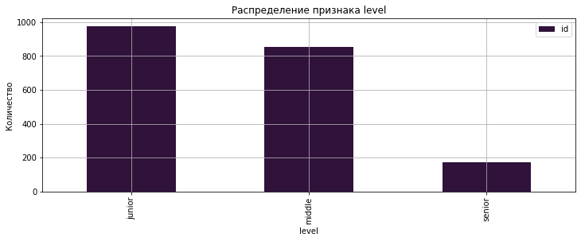

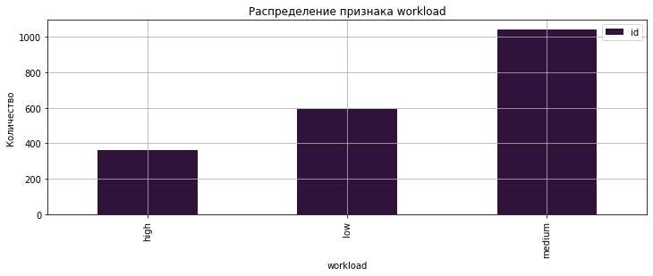

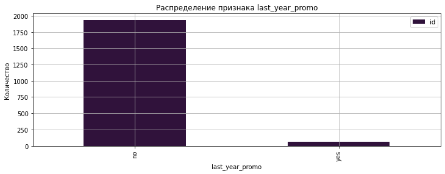

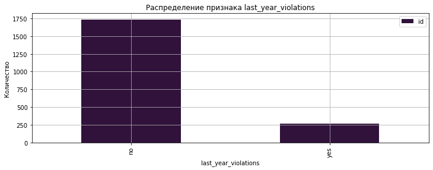

```python
plt.rcParams.update({'font.size': 10})
for i in test_features[['dept', 'level', 'workload', 'last_year_promo', 'last_year_violations']]:
    test_features.pivot_table(index=i,
                         values='id',
                         aggfunc='count').plot(kind='bar',
                                               grid=True,
                                               title= f'Распределение признака {i}',
                                               colormap="turbo", figsize=(12,4));
    plt.ylabel('Количество')
    plt.show()
```

**Выводы по графикам качественных признаков:**

- По распределению признака "dept", можно сказать, что больше всего сотрудников работают в отделе sales.
- По распределению признака "level", можно сказать, что больше всего сотрудников имеют уровень занимаемой должности junior.
- По распределению признака "workload", можно сказать, что больше всего сотрудников имеют уровень загруженности medium.
- По распределению признака "last_year_promo", можно сказать, что чаще сотрудникам не повышали заработную плату за последний год.
- По распределению признака "last_year_violations", можно сказать, что чаще сотрудники не нарушали трудовой договор за последний год;
- По распределению признака "supervisor_evaluation", можно сказать, что чаще сотрудники получают оценку качества от руководителя 4.

### Построим графики для каждого признака датасета `test_target_job`

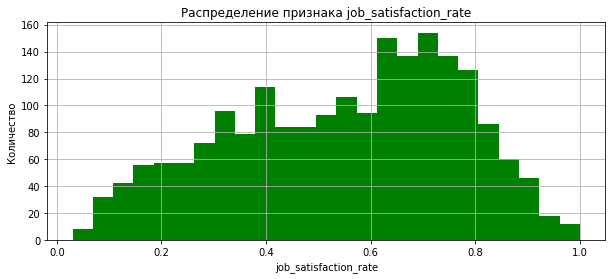

```python
test_target_job['job_satisfaction_rate'].plot(kind='hist', grid=True, title='Распределение признака job_satisfaction_rate', bins=25, color='green', figsize=(10,4));
plt.xlabel('job_satisfaction_rate')
plt.ylabel('Количество')
plt.show()
```

Также построим график "ящики с усами", который покажет выбросы и основные статистики данных (квартили)

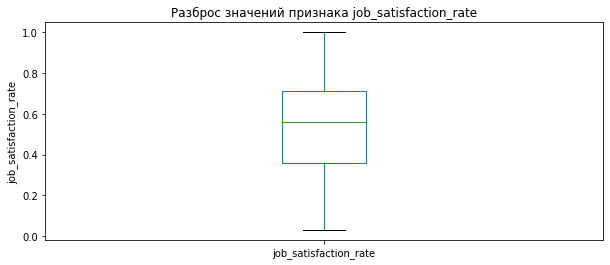

```python
plt.rcParams.update({'font.size': 10})
train_job['job_satisfaction_rate'].plot(kind='box', title = 'Разброс значений признака job_satisfaction_rate', figsize=(10,4))
plt.ylabel('job_satisfaction_rate')
plt.show();
```

**Выводы по графикам количественных признаков:**

- По графикам можно сказать, что признаки распределены не равномерно, сильных выбросов не наблюдается.

### Вывод по исследовательскому анализу данных

**Выводы по графикам качественных признаков:**

- По распределению признака "dept", можно сказать, что больше всего сотрудников работают в отделе sales.
- По распределению признака "level", можно сказать, что больше всего сотрудников имеют уровень занимаемой должности junior.
- По распределению признака "workload", можно сказать, что больше всего сотрудников имеют уровень загруженности medium.
- По распределению признака "last_year_promo", можно сказать, что чаще сотрудникам не повышали заработную плату за последний год.
- По распределению признака "last_year_violations", можно сказать, что чаще сотрудники не нарушали трудовой договор за последний год.

**Выводы по графикам количественных признаков:**

- По графикам можно сказать, что признаки распределены не равномерно, имеются выбросы.

**На следующем этапе подготовки данных необходимо:**

- подготовить категориальные признаки с заполнением пропусков;
- подготовить количественные непрерывные признаки с помощью стандартизации.

### Выполним анализ корреляции датасета train_job

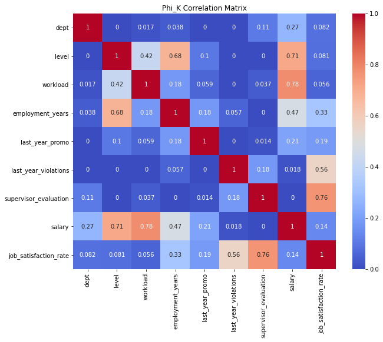

```python
corr_matrix = train_job.drop(['id'], axis =1).phik_matrix(interval_cols=['job_satisfaction_rate', 'salary'])

# Визуализируем матрицу корреляции
plt.figure(figsize=(10, 8))
sns.heatmap(corr_matrix, annot=True, cmap='coolwarm')
plt.title('Phi_K Correlation Matrix')
plt.show()
```

Согласно получившейся матрицы корреляции следует, что заметная прямая связь наблюдается у признаков:

- `employment_years` и `level`;
- `last_year_violations` и `job_satisfaction_rate`.

Высокая взаимосвязь наблюдается у признаков:

- `level` и `salary`;
- `salary` и `workload`;
- `job_satisfaction_rate` и `supervisor_evaluation`.

### Выполним анализ корреляции датасета test_features

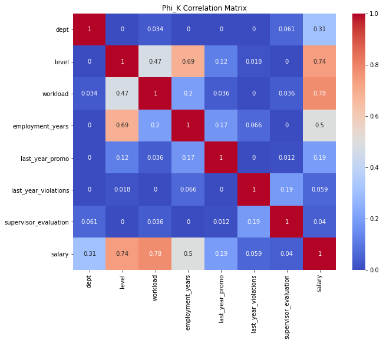

```python
# Вычислим матрицу корреляции с использованием phik
corr_matrix = test_features.drop(['id'], axis =1).phik_matrix(interval_cols=['salary'])

# Визуализируем матрицу корреляции
plt.figure(figsize=(10, 8))
sns.heatmap(corr_matrix, annot=True, cmap='coolwarm')
plt.title('Phi_K Correlation Matrix')
plt.show()
```

Согласно получившейся матрицы корреляции следует, что заметная прямая связь наблюдается у признаков:

- `employment_years` и `level`;
- `employment_years` и `salary`.

Высокая взаимосвязь наблюдается у признаков:

- `level` и `salary`;
- `salary` и `workload`.

## Задача №1. Подготовка данных

На данном этапе необходимо выполнить подготовку признаков в пайплайне, дополнив пайплайн шага предобработки. При кодировании учитывать особенности признаков и моделей и использовать как минимум два кодировщика.

```python
test_features_target_job = test_features.merge(test_target_job, how='left', on=['id'])
```

```python
train_job.set_index('id').duplicated().sum()
```

```
245
```

```python
train_job = train_job.set_index('id').drop_duplicates()
```

```python
# загружаем данные
X_train = train_job.drop(['job_satisfaction_rate'], axis=1)
y_train = train_job['job_satisfaction_rate']
X_test = test_features_target_job.drop(['job_satisfaction_rate'], axis=1)
y_test = test_features_target_job['job_satisfaction_rate']
```

```python
# создаём списки с названиями признаков
ohe_columns = ['dept', 'last_year_promo', 'last_year_violations']
ord_columns = ['level', 'workload']
num_columns = ['employment_years', 'supervisor_evaluation', 'salary']
```

```python
# создаём пайплайн для подготовки признаков из списка ohe_columns: заполнение пропусков и OHE-кодирование
# SimpleImputer + OHE
ohe_pipe = Pipeline(
    [('simpleImputer_ohe', SimpleImputer(missing_values=np.nan, strategy='most_frequent')),
     ('ohe', OneHotEncoder(drop='first', handle_unknown='ignore', sparse_output=False))])
```

```python
# создаём пайплайн для подготовки признаков из списка ord_columns: заполнение пропусков и Ordinal-кодирование
# SimpleImputer + OE
ord_pipe = Pipeline(
    [('simpleImputer_before_ord', SimpleImputer(missing_values=np.nan, strategy='most_frequent')),
     ('ord',  OrdinalEncoder(
                categories=[['junior', 'middle', 'senior'],
                            ['low', 'medium', 'high']],
                handle_unknown='use_encoded_value', unknown_value=np.nan)),
     ('simpleImputer_after_ord', SimpleImputer(missing_values=np.nan, strategy='most_frequent'))])

# создаём общий пайплайн для подготовки данных
data_preprocessor = ColumnTransformer(
    [('ohe', ohe_pipe, ohe_columns),
     ('ord', ord_pipe, ord_columns),
     ('num', StandardScaler(), num_columns)
    ],
    remainder='passthrough')
```

## Задача №1. Обучение моделей

На данном шаге необходимо обучить как минимум две модели. Взять одну линейную модель, а в качестве второй — дерево решений. Подобрать гиперпараметры как минимум для одной модели с помощью одного из известных вам инструментов.

Выбрать лучшую модель и проверить её качество. Выбор делать на основе новой метрики — SMAPE (англ. symmetric mean absolute percentage error, «симметричное среднее абсолютное процентное отклонение»).

Написать функцию, которая принимает на вход массивы NumPy или объекты Series в pandas и возвращает значение метрики SMAPE. Использовать эту метрику при подборе гиперпараметров и оценке качества моделей.

Критерий успеха: SMAPE ≤ 15 на тестовой выборке.

### Создадим итоговый пайплайн

```python
# создаём итоговый пайплайн: подготовка данных и модель
pipe_final = Pipeline([
    ('preprocessor', data_preprocessor),
    ('models', DecisionTreeRegressor(random_state=RANDOM_STATE))])

param_grid = [
    {'models': [DecisionTreeRegressor(random_state=RANDOM_STATE)],
     'models__max_depth': range(2,50),
     'models__max_features': range(2,40),
     'models__min_samples_leaf': range(1,50),
     'models__min_samples_split': range(2,50)},

    {'models': [LinearRegression()]},

    {'models': [Ridge(random_state=RANDOM_STATE)],
     'models__alpha': [0.1, 0.5, 1, 5, 10, 50]}]
```

### Напишем функцию, которая возвращает значение метрики SMAPE

```python
def smape(y_test, pred):
    metric = 100/len(y_test) * np.sum(2 * np.abs(pred - y_test) / (np.abs(y_test) + np.abs(pred)))
    return metric
scorer_smape = make_scorer(smape, greater_is_better=False)
```

### Найдем лучшую модель и ее параметры

```python
randomized_search = RandomizedSearchCV(
    pipe_final,
    param_grid,
    random_state=RANDOM_STATE,
    scoring = scorer_smape,
    n_jobs=-1,
    error_score='raise')
randomized_search.fit(X_train, y_train)

print('Лучшая модель и её параметры:\n\n', randomized_search.best_estimator_)
print('Метрика SMAPE для лучшей модели на тренировочных данных:', -1*randomized_search.best_score_)
```

```
Лучшая модель и её параметры:

 Pipeline(steps=[('preprocessor',
                 ColumnTransformer(remainder='passthrough',
                                   transformers=[('ohe',
                                                  Pipeline(steps=[('simpleImputer_ohe',
                                                                   SimpleImputer(strategy='most_frequent')),
                                                                  ('ohe',
                                                                   OneHotEncoder(drop='first',
                                                                                 handle_unknown='ignore',
                                                                                 sparse_output=False))]),
                                                  ['dept', 'last_year_promo',
                                                   'last_year_violations']),
                                                 ('ord',
                                                  Pipeline(steps=[('simpleImputer_befor...
                                                                                               'high']],
                                                                                  handle_unknown='use_encoded_value',
                                                                                  unknown_value=nan)),
                                                                  ('simpleImputer_after_ord',
                                                                   SimpleImputer(strategy='most_frequent'))]),
                                                  ['level', 'workload']),
                                                 ('num', StandardScaler(),
                                                  ['employment_years',
                                                   'supervisor_evaluation',
                                                   'salary'])])),
                ('models',
                 DecisionTreeRegressor(max_depth=14, max_features=29,
                                       min_samples_leaf=2, min_samples_split=12,
                                       random_state=42))])
Метрика SMAPE для лучшей модели на тренировочных данных: 15.382967554928232
```

### Найдем метрику SMAPE на тестовых данных

```python
pred=randomized_search.predict(X_test)
print(f'Метрика SMAPE на тестовой выборке: {smape(y_test, pred)}')
```

```
Метрика SMAPE на тестовой выборке: 13.664985199249342
```

### Проверим лучшую модель на адекватность

Проверим лучшую модель на адекватность, сравнив качество её предсказаний с качеством модели, которая предсказывала бы константу. В качестве константной модели будем использовать `DummyRegressor`.

```python
dummy_regr = DummyRegressor(strategy="mean")
dummy_regr.fit(X_train, y_train)
pred_reg = dummy_regr.predict(X_test)
print(f'Метрика SMAPE модели DummyRegressor: {round(smape(y_test, pred_reg))}')
```

```
Метрика SMAPE модели DummyRegressor: 38
```

Результат тестирования нашей модели на тествой выборке лучше, чем результат константной модели, что подтверждает адекватность лучшей модели.

## Задача №1. Оформление выводов

- Модель DecisionTreeRegressor с гипермараметрами (max_depth=14, max_features=29, min_samples_leaf=2, min_samples_split=12, random_state=42) является лучшей.
- Метрика SMAPE на тестовых данных для лучшей модели показала результат 14, по условию критерий успеха: SMAPE ≤ 15, что по итогу выполнено.

# Задача №2 - Предсказание увольнения сотрудника из компании

## Задача №2. Загрузка данных

```python
try:
    train_quit = pd.read_csv('train_quit.csv', decimal=",")
    test_target_quit = pd.read_csv('test_target_quit.csv', decimal=",")
except:
    train_quit = pd.read_csv('https://code.s3.yandex.net/datasets/train_quit.csv', encoding='utf8', decimal=",")
    test_target_quit = pd.read_csv('https://code.s3.yandex.net/datasets/test_target_quit.csv', encoding='utf8', decimal=",")
```

```python
train_quit.head(3)
```

|  | id | dept | level | workload | employment_years | last_year_promo | last_year_violations | supervisor_evaluation | salary | quit |
| --- | --- | --- | --- | --- | --- | --- | --- | --- | --- | --- |
| 0 | 723290 | sales | middle | high | 2 | no | no | 4 | 54000 | no |
| 1 | 814010 | sales | junior | medium | 2 | no | no | 4 | 27600 | no |
| 2 | 155091 | purchasing | middle | medium | 5 | no | no | 1 | 37200 | no |

```python
train_quit.info()
```

```
<class 'pandas.core.frame.DataFrame'>
RangeIndex: 4000 entries, 0 to 3999
Data columns (total 10 columns):
 #   Column                 Non-Null Count  Dtype
---  ------                 --------------  -----
 0   id                     4000 non-null   int64
 1   dept                   4000 non-null   object
 2   level                  4000 non-null   object
 3   workload               4000 non-null   object
 4   employment_years       4000 non-null   int64
 5   last_year_promo        4000 non-null   object
 6   last_year_violations   4000 non-null   object
 7   supervisor_evaluation  4000 non-null   int64
 8   salary                 4000 non-null   int64
 9   quit                   4000 non-null   object
dtypes: int64(4), object(6)
memory usage: 312.6+ KB
```

```python
test_target_quit.head(3)
```

|  | id | quit |
| --- | --- | --- |
| 0 | 999029 | yes |
| 1 | 372846 | no |
| 2 | 726767 | no |

```python
test_target_quit.info()
```

```
<class 'pandas.core.frame.DataFrame'>
RangeIndex: 2000 entries, 0 to 1999
Data columns (total 2 columns):
 #   Column  Non-Null Count  Dtype
---  ------  --------------  -----
 0   id      2000 non-null   int64
 1   quit    2000 non-null   object
dtypes: int64(1), object(1)
memory usage: 31.4+ KB
```

**Выводы по загрузке и изучению данных:**

По первичной информации данные в таблицах соответствуют описанию.

## Задача №2. Предобработка данных

На данном шаге проверим данные на наличие пропусков и дубликатов. Узнаем, корректны ли типы данных у каждого признака. При необходимости устраним проблемы с данными. Пропуски в данных заполним в пайплайне.

### Проверим данные на наличие неявных дубликатов и ошибок

```python
train_quit['dept'].unique()
```

```
array(['sales', 'purchasing', 'marketing', 'technology', 'hr'],
      dtype=object)
```

```python
train_quit['level'].unique()
```

```
array(['middle', 'junior', 'sinior'], dtype=object)
```

```python
train_quit.loc[train_quit['level']== 'sinior', 'level'] = 'senior'
```

```python
train_quit['workload'].unique()
```

```
array(['high', 'medium', 'low'], dtype=object)
```

```python
train_quit['last_year_promo'].unique()
```

```
array(['no', 'yes'], dtype=object)
```

```python
train_quit['last_year_violations'].unique()
```

```
array(['no', 'yes'], dtype=object)
```

```python
train_quit['supervisor_evaluation'].unique()
```

```
array([4, 1, 3, 5, 2], dtype=int64)
```

```python
train_quit['quit'].unique()
```

```
array(['no', 'yes'], dtype=object)
```

```python
test_target_quit['quit'].unique()
```

```
array(['yes', 'no'], dtype=object)
```

### Проверим данные на наличие явных дубликатов

```python
print('Количество явных дубликатов в датасете train_job:', train_quit.duplicated().sum())
print('Количество явных дубликатов в датасете test_target_job:', test_target_quit.duplicated().sum())
```

```
Количество явных дубликатов в датасете train_job: 0
Количество явных дубликатов в датасете test_target_job: 0
```

### Выводы по предобработке данных

По итогам предобработке данных:

- проверили пропуски в данных;
- проверили данные на явные и неявные дубликаты.

## Задача №2. Исследовательский анализ данных

На данном этапе необходимо провести исследовательский анализ данных, составить портрет «уволившегося сотрудника», проверить утверждение: "уровень удовлетворённости сотрудника работой в компании влияет на то, уволится ли сотрудник".

### Проведем исследовательский анализ данных

```python
train_quit.describe()
```

|  | id | employment_years | supervisor_evaluation | salary |
| --- | --- | --- | --- | --- |
| count | 4000.000000 | 4000.000000 | 4000.000000 | 4000.000000 |
| mean | 552099.283750 | 3.701500 | 3.474750 | 33805.800000 |
| std | 260158.031387 | 2.541852 | 1.004049 | 15152.415163 |
| min | 100222.000000 | 1.000000 | 1.000000 | 12000.000000 |
| 25% | 327785.750000 | 2.000000 | 3.000000 | 22800.000000 |
| 50% | 546673.000000 | 3.000000 | 4.000000 | 30000.000000 |
| 75% | 781497.750000 | 6.000000 | 4.000000 | 43200.000000 |
| max | 999915.000000 | 10.000000 | 5.000000 | 96000.000000 |

По анализу таблицы описательной статистики признаков датасета `train_quit` выбросы и аномалии не наблюдаются.

### Построим графики для каждого признака датасета `train_quit`

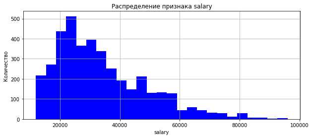

```python
train_quit['salary'].plot(kind='hist', grid=True, title='Распределение признака salary', bins=25, color='blue', figsize=(10,4));
plt.xlabel('salary')
plt.ylabel('Количество')
plt.show()
```

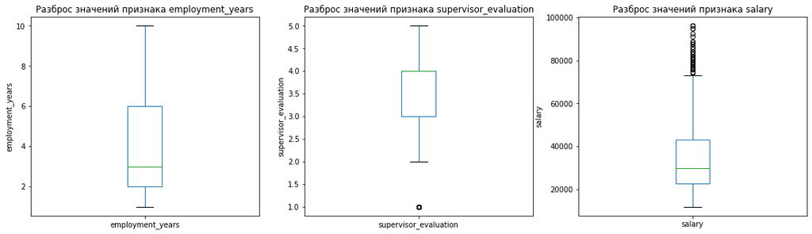

```python
plt.rcParams.update({'font.size': 10})
fig, axes = plt.subplots(nrows=1, ncols=3, figsize=(19,5))
axes[0].set_title('Разброс значений признака employment_years')
axes[0].set_ylabel('employment_years')
train_quit['employment_years'].plot(kind='box', ax=axes[0])

axes[1].set_title('Разброс значений признака supervisor_evaluation')
axes[1].set_ylabel('supervisor_evaluation')
train_quit['supervisor_evaluation'].plot(kind='box', ax=axes[1])

axes[2].set_title('Разброс значений признака salary')
axes[2].set_ylabel('salary')
train_quit['salary'].plot(kind='box', ax=axes[2])
plt.show();
```

**Выводы по графикам количественных признаков:**

- По графикам можно сказать, что признаки распределены не равномерно, имеются выбросы. Выбросы на графике "ящик с усами" по заработной плате сотрудников, не будем считать выбросами и аномалиями, аналогично как и в задаче №1, так как если их убрать, модель может переобучиться. Для этого подберем скалер, который устойчив к выбросам.

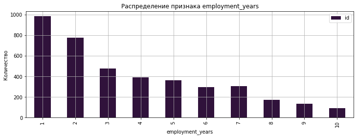

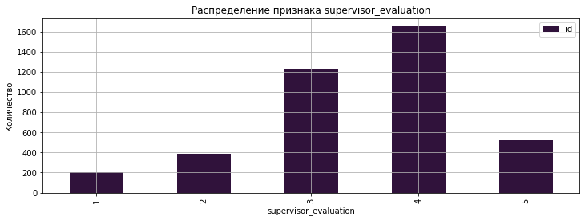

```python
plt.rcParams.update({'font.size': 10})
for i in train_quit[['employment_years', 'supervisor_evaluation']]:
    train_quit.pivot_table(index=i,
                         values='id',
                         aggfunc='count').plot(kind='bar',
                                               grid=True,
                                               title= f'Распределение признака {i}',
                                               colormap="turbo", figsize=(12,4));
    plt.ylabel('Количество')
    plt.show()
```

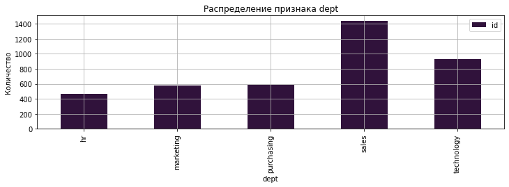

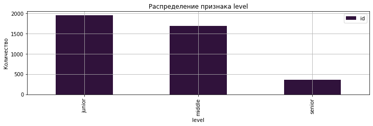

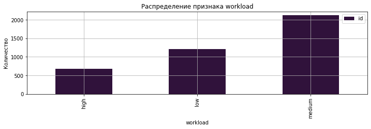

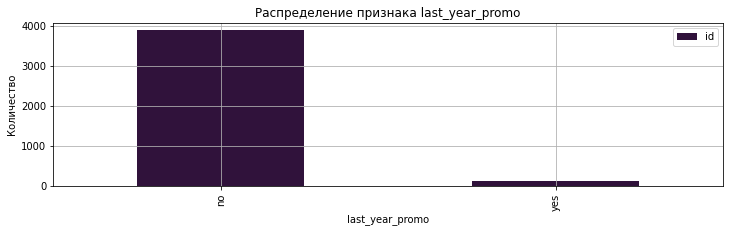

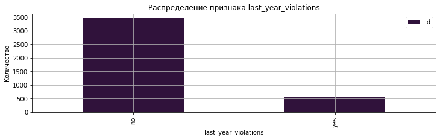

```python
plt.rcParams.update({'font.size': 10})
for i in train_quit[['dept', 'level', 'workload', 'last_year_promo', 'last_year_violations']]:
    train_quit.pivot_table(index=i,
                         values='id',
                         aggfunc='count').plot(kind='bar',
                                               grid=True,
                                               title= f'Распределение признака {i}',
                                               colormap="turbo", figsize=(12,3));
    plt.ylabel('Количество')
    plt.show()
```

**Выводы по графикам качественных признаков:**

- По распределению признака "dept", можно сказать, что больше всего сотрудников работают в отделе sales.
- По распределению признака "level", можно сказать, что больше всего сотрудников имеют уровень занимаемой должности junior.
- По распределению признака "workload", можно сказать, что больше всего сотрудников имеют уровень загруженности medium.
- По распределению признака "last_year_promo", можно сказать, что чаще сотрудникам не повышали заработную плату за последний год.
- По распределению признака "last_year_violations", можно сказать, что чаще сотрудники не нарушали трудовой договор за последний год.
- По распределению признака "supervisor_evaluation", можно сказать, что чаще сотрудники получают оценку качества от руководителя 4.

### Выполним анализ корреляции датасета train_quit

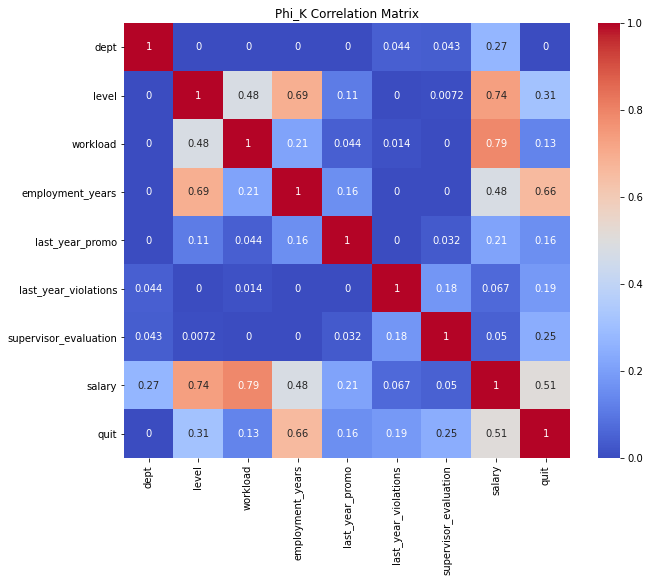

```python
# Вычислим матрицу корреляции с использованием phik
corr_matrix = train_quit.drop(['id'], axis =1).phik_matrix(interval_cols=['salary', 'job_satisfaction_rate'])

# Визуализируем матрицу корреляции
plt.figure(figsize=(10, 8))
sns.heatmap(corr_matrix, annot=True, cmap='coolwarm')
plt.title('Phi_K Correlation Matrix')
plt.show()
```

### Построим графики для каждого признака датасета `test_target_quit`

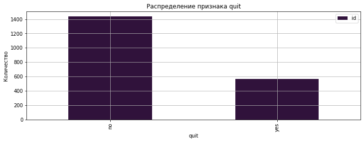

```python
plt.rcParams.update({'font.size': 10})
test_target_quit.pivot_table(index='quit',
                             values='id',
                             aggfunc='count').plot(kind='bar',
                                                   grid=True, title='Распределение признака quit',
                                                   colormap="turbo",
                                                   figsize=(12,4));
plt.ylabel('Количество')
plt.show()
```

**Выводы по графику качественного признака:**

- По распределению признака "quit", можно сказать, что чаще всего сотрудники не увольняются из компании.

### Составим портрет «уволившегося сотрудника»

Отберем сотрудников, которые уволились и тех, кто не уволился и посмотрим на разницу данных сотрудников по средней длительности работы, средней ежемесячной зарплате, загруженности, сферы и уровня занимаемой должности.

```python
quit_yes = train_quit.query('quit=="yes"')
quit_no = train_quit.query('quit=="no"')
#quit_yes.head(3)
#quit_no.head(3)
```

```python
mean_employment_quit_yes = quit_yes['employment_years'].mean()
mean_employment_quit_no = quit_no['employment_years'].mean()
print(f'Cредняя длительность работы в компании уволившегося сотрудника - {round(mean_employment_quit_yes)} года')
print(f'Средняя длительность работы в компании не уволившегося сотрудника - {round(mean_employment_quit_no)} года')
print(f'Разница составляет {round((mean_employment_quit_no - mean_employment_quit_yes))} года')
```

```
Cредняя длительность работы в компании уволившегося сотрудника - 2 года
Средняя длительность работы в компании не уволившегося сотрудника - 4 года
Разница составляет 3 года
```

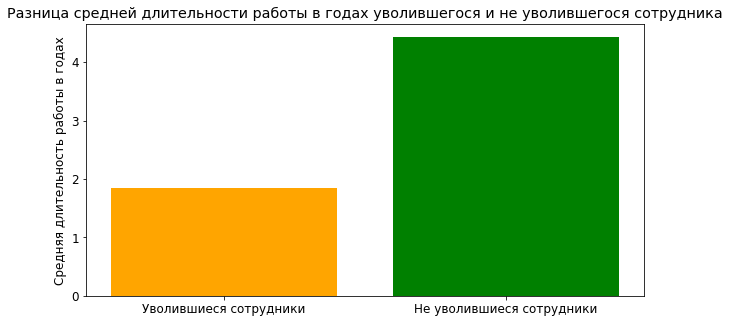

```python
plt.rcParams.update({'font.size': 12})
plt.figure(figsize=(10, 5))
plt.bar(['Уволившиеся сотрудники', 'Не уволившиеся сотрудники'], [mean_employment_quit_yes, mean_employment_quit_no], color=["orange", "green"])
plt.title('Разница средней длительности работы в годах уволившегося и не уволившегося сотрудника')
plt.ylabel('Средняя длительность работы в годах')
plt.show()
```

По графику и расчетам можно сказать, что сотрудник, который уволился в среднем работал в компании на три года меньше, чем сотрудник, который не уволился.

```python
mean_salary_quit_yes = quit_yes['salary'].mean()
mean_salary_quit_no = quit_no['salary'].mean()
print(f'Cредняя зарплата уволившегося сотрудника - {round(mean_salary_quit_yes,2)}')
print(f'Средняя зарплата не уволившегося сотрудника - {round(mean_salary_quit_no,2)}')
print(f'Разница составляет {round((mean_salary_quit_no - mean_salary_quit_yes),2)}')
```

```
Cредняя зарплата уволившегося сотрудника - 23885.11
Средняя зарплата не уволившегося сотрудника - 37702.23
Разница составляет 13817.12
```

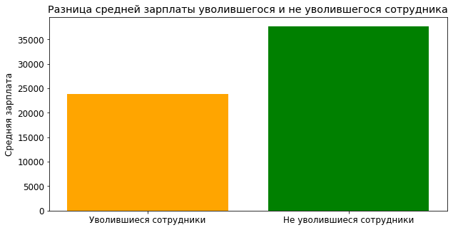

```python
plt.rcParams.update({'font.size': 12})
plt.figure(figsize=(10, 5))
plt.bar(['Уволившиеся сотрудники', 'Не уволившиеся сотрудники'], [mean_salary_quit_yes, mean_salary_quit_no], color=["orange", "green"])
plt.title('Разница средней зарплаты уволившегося и не уволившегося сотрудника')
plt.ylabel('Средняя зарплата')
plt.show()
```

По графику и расчетам можно сказать, что сотрудник, который уволился в среднем имел зарплату на 13817.12 меньше, чем сотрудник, который не уволился.

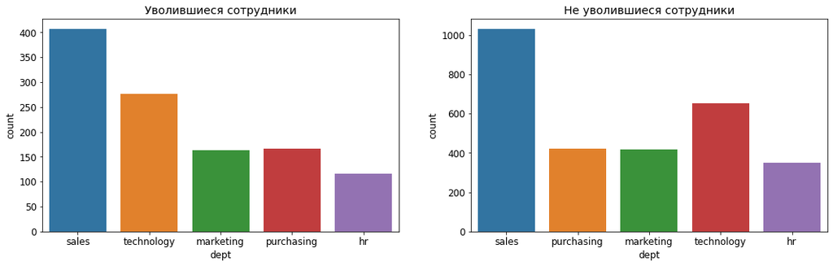

```python
fig, axes = plt.subplots(nrows=1, ncols=2, figsize=(18,5))

sns.countplot(x='dept', data=quit_yes, ax=axes[0])
axes[0].set_title('Уволившиеся сотрудники')

sns.countplot(x='dept', data=quit_no, ax=axes[1])
axes[1].set_title('Не уволившиеся сотрудники')
plt.show()
```

```python
quit_yes['dept'].value_counts(normalize=True)
```

```
sales         0.360816
technology    0.244681
purchasing    0.147163
marketing     0.144504
hr            0.102837
Name: dept, dtype: float64
```

```python
quit_no['dept'].value_counts(normalize=True)
```

```
sales         0.358983
technology    0.227019
purchasing    0.146936
marketing     0.145891
hr            0.121170
Name: dept, dtype: float64
```

По графикам и расчетам можно сказать, что сотрудник, который уволился работал в 'sales', также как и сотрудник, который не уволился. Это обусловлено тем, что изначально в данных больше информации о сотрудниках в 'sales'.

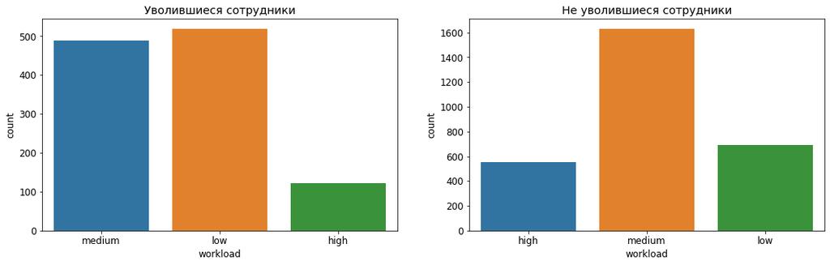

```python
fig, axes = plt.subplots(nrows=1, ncols=2, figsize=(18,5))

sns.countplot(x='workload', data=quit_yes, ax=axes[0])
axes[0].set_title('Уволившиеся сотрудники')

sns.countplot(x='workload', data=quit_no, ax=axes[1])
axes[1].set_title('Не уволившиеся сотрудники')
plt.show()
```

```python
quit_yes['workload'].value_counts(normalize=True)
```

```
low       0.460106
medium    0.432624
high      0.107270
Name: workload, dtype: float64
```

```python
quit_no['workload'].value_counts(normalize=True)
```

```
medium    0.567549
low       0.239903
high      0.192549
Name: workload, dtype: float64
```

По графикам и расчетам можно сказать, что сотрудник, который уволился имеет уровень загруженности сотрудника 'low', а также 'medium'. Это, может быть, обусловлено тем, что обязанности на занимаеймой должности сотрудника не оправдывают своих ожиданий.

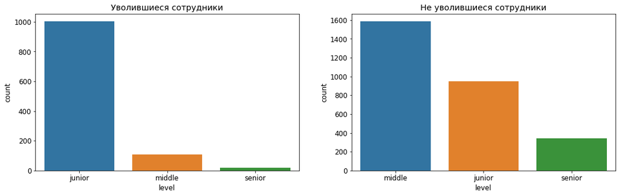

```python
fig, axes = plt.subplots(nrows=1, ncols=2, figsize=(18,5))

sns.countplot(x='level', data=quit_yes, ax=axes[0])
axes[0].set_title('Уволившиеся сотрудники')

sns.countplot(x='level', data=quit_no, ax=axes[1])
axes[1].set_title('Не уволившиеся сотрудники')
plt.show()
```

```python
quit_yes['level'].value_counts(normalize=True)
```

```
junior    0.889184
middle    0.095745
senior    0.015071
Name: level, dtype: float64
```

```python
quit_no['level'].value_counts(normalize=True)
```

```
middle    0.552228
junior    0.329387
senior    0.118384
Name: level, dtype: float64
```

По графикам и расчетам можно сказать, что сотрудник, который уволился имеет уровень занимаемой должности 'junior'. Это, может быть, обусловлено тем, что заработная плата сотрудников такого уровня должности не оправдывает своих ожиданий.

**Портрет «уволившегося сотрудника»:** Сотрудник в сфере 'sales', со средней длительностью работы в компании - 2 года; средней зарплатой - 23885.11; с уровенем загруженности 'low'; с уровнем занимаемой должности - 'junior'.

### Проверим утверждение: "уровень удовлетворённости сотрудника работой в компании влияет на то, уволится ли сотрудник"

```python
test_quit_merge = test_features_target_job.merge(test_target_quit, on='id')
```

Построим график "ящик с усами" для наглядности распределения данных по уровню удовлетворенности работой.

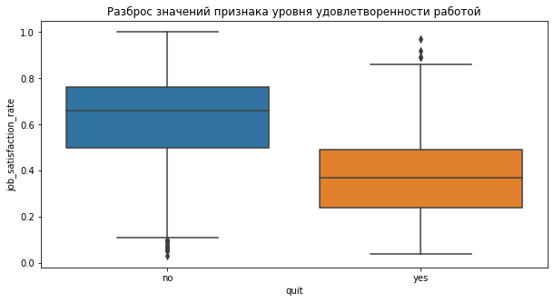

```python
plt.rcParams.update({'font.size': 10})
plt.figure(figsize=(10, 5))
sns.boxplot(x='quit', y='job_satisfaction_rate', data=test_quit_merge)
plt.title('Разброс значений признака уровня удовлетворенности работой')
plt.show();
```

По графику "ящик с усами" видно, что уровень удовлетворенности работой не уволившегося сотрудника выше уровня удовлетворенности работой уволившегося сотрудника. Также отмечаются выбросы, проявляющиеся в виде уволившихся сотрудников, которые были удовлетворены работой, и сотрудников, которые продолжают работать с низким уровнем удовлетворенности от работы.

### Выводы по исследовательскому анализу данных

**Выводы по графикам количественных признаков:**

- По графикам можно сказать, что признаки распределены не равномерно, имеются выбросы. Выбросы на графике "ящик с усами" по заработной плате сотрудников, не будем считать выбросами и аномалиями, аналогично как и в задаче №1, так как если их убрать, модель может переобучиться. Для этого подберем скалер, который устойчив к выбросам.

**Выводы по графикам качественных признаков:**

- По распределению признака "dept", можно сказать, что больше всего сотрудников работают в отделе sales.
- По распределению признака "level", можно сказать, что больше всего сотрудников имеют уровень занимаемой должности junior.
- По распределению признака "workload", можно сказать, что больше всего сотрудников имеют уровень загруженности medium.
- По распределению признака "last_year_promo", можно сказать, что чаще сотрудникам не повышали заработную плату за последний год.
- По распределению признака "last_year_violations", можно сказать, что чаще сотрудники не нарушали трудовой договор за последний год.
- По распределению признака "quit", можно сказать, что чаще всего сотрудники не увольняются из компании.

**Портрет «уволившегося сотрудника»:** Сотрудник в сфере 'sales', со средней длительностью работы в компании - 2 года; средней зарплатой - 23885.11; с уровенем загруженности 'low'; с уровнем занимаемой должности - 'junior'.

Уровень удовлетворенности работой не уволившегося сотрудника выше уровня удовлетворенности работой уволившегося сотрудника. Также отмечаются выбросы, проявляющиеся в виде уволившихся сотрудников, которые были удовлетворены работой, и сотрудников, которые продолжают работать с низким уровнем удовлетворенности от работы.

## Задача №2. Добавление нового входного признака

На данном этапе необходимо добавить `job_satisfaction_rate`, предсказанный лучшей моделью первой задачи, к входным признакам второй задачи.

```python
pred_quit = randomized_search.predict(train_quit)
```

```python
train_quit['job_satisfaction_rate'] = pred_quit
```

```python
test_quit_merge['job_satisfaction_rate'] = pred
```

## Задача №2. Подготовка данных

На данном этапе необходимо выполнить подготовку в пайплайне, дополнив пайплайн предобработки. При кодировании учитывать особенности признаков и моделей и использовать как минимум два кодировщика.

```python
train_quit.set_index('id').duplicated().sum()
```

```
1413
```

```python
train_quit = train_quit.set_index('id').drop_duplicates()
```

```python
# Выполним кодирование целевого признака с помощью LabelEncoder
y_train_2 = train_quit['quit']
y_test_2 = test_quit_merge['quit']

label_encoder = LabelEncoder()
label_encoder.fit(y_train_2)

y_train_2 = label_encoder.transform(y_train_2)
y_test_2 = label_encoder.transform(y_test_2)
```

```python
# загружаем данные
X_train_2 = train_quit.drop(['quit', 'dept'], axis=1)
X_test_2 = test_quit_merge.drop(['quit', 'dept'], axis=1)

# создаём списки с названиями признаков
ohe_columns_2 = ['last_year_promo', 'last_year_violations']
ord_columns_2 = ['level', 'workload']
num_columns_2 = ['employment_years', 'salary', 'job_satisfaction_rate', 'supervisor_evaluation']

# создаём пайплайн для подготовки признаков из списка ohe_columns: заполнение пропусков и OHE-кодирование
# SimpleImputer + OHE
ohe_pipe_2 = Pipeline(
    [('simpleImputer_ohe', SimpleImputer(missing_values=np.nan, strategy='most_frequent')),
     ('ohe', OneHotEncoder(drop='first', handle_unknown='error', sparse_output=False))])

# создаём пайплайн для подготовки признаков из списка ord_columns: заполнение пропусков и Ordinal-кодирование
# SimpleImputer + OE
ord_pipe_2 = Pipeline(
    [('simpleImputer_before_ord', SimpleImputer(missing_values=np.nan, strategy='most_frequent')),
     ('ord',  OrdinalEncoder(
                categories=[['middle', 'junior', 'senior'],
                            ['high', 'medium', 'low']],
         handle_unknown='use_encoded_value', unknown_value=np.nan)),
     ('simpleImputer_after_ord', SimpleImputer(missing_values=np.nan, strategy='most_frequent'))])

# создаём общий пайплайн для подготовки данных
data_preprocessor_2 = ColumnTransformer(
    [('ohe', ohe_pipe_2, ohe_columns_2),
     ('ord', ord_pipe_2, ord_columns_2),
     ('num', StandardScaler(), num_columns_2)
    ],
    remainder='passthrough')
```

## Задача №2. Обучение модели

На данном этапе следует обучить как минимум три модели. Как минимум для двух из них подобрать гиперпараметры. Проверить качество лучшей модели.

Метрика оценки качества в этой задаче — ROC-AUC. Критерий успеха: ROC-AUC ≥ 0.91 на тестовой выборке.

### Создадим итоговый пайплайн

```python
#создаём итоговый пайплайн: подготовка данных и модель
pipe_final_2 = Pipeline([
    ('preprocessor', data_preprocessor_2),
    ('models', DecisionTreeClassifier(random_state=RANDOM_STATE))])

param_grid_2 = [
    {'models': [DecisionTreeClassifier(random_state=RANDOM_STATE)],
     'models__max_depth': (None, *range(2, 50)),
     'models__min_samples_split': range(2, 40),
     'models__min_samples_leaf': range(1, 20)},

    {'models': [LogisticRegression(
        random_state=RANDOM_STATE,
        solver='liblinear',
        penalty='l1')],
     'models__C': range(1,10)},

    {'models': [SVC(random_state=RANDOM_STATE, probability=True)],
     'models__C':[0.1,1,10],
     'models__kernel':['linear'],
     'models__degree':[1,3,4],
     'models__gamma':[1, 0.1, 0.01]}]
```

### Найдем лучшую модель и ее параметры

```python
randomized_search_2 = RandomizedSearchCV(
    pipe_final_2,
    param_grid_2,
    scoring='roc_auc',
    random_state=RANDOM_STATE,
    n_jobs=-1,
    error_score='raise')
randomized_search_2.fit(X_train_2, y_train_2)

print('Лучшая модель и её параметры:\n\n', randomized_search_2.best_estimator_)
print('Метрика ROC-AUC для лучшей модели на тренировочных данных:', randomized_search_2.best_score_)
```

```
Лучшая модель и её параметры:

 Pipeline(steps=[('preprocessor',
                 ColumnTransformer(remainder='passthrough',
                                   transformers=[('ohe',
                                                  Pipeline(steps=[('simpleImputer_ohe',
                                                                   SimpleImputer(strategy='most_frequent')),
                                                                  ('ohe',
                                                                   OneHotEncoder(drop='first',
                                                                                 sparse_output=False))]),
                                                  ['last_year_promo',
                                                   'last_year_violations']),
                                                 ('ord',
                                                  Pipeline(steps=[('simpleImputer_before_ord',
                                                                   SimpleImputer(strategy='...
                                                                                  handle_unknown='use_encoded_value',
                                                                                  unknown_value=nan)),
                                                                  ('simpleImputer_after_ord',
                                                                   SimpleImputer(strategy='most_frequent'))]),
                                                  ['level', 'workload']),
                                                 ('num', StandardScaler(),
                                                  ['employment_years', 'salary',
                                                   'job_satisfaction_rate',
                                                   'supervisor_evaluation'])])),
                ('models',
                 DecisionTreeClassifier(max_depth=31, min_samples_leaf=8,
                                        min_samples_split=38,
                                        random_state=42))])
Метрика ROC-AUC для лучшей модели на тренировочных данных: 0.8926815681626113
```

### Найдем метрику ROC-AUC на тестовых данных

```python
pred_2=randomized_search_2.predict_proba(X_test_2)[:,1]
print(f'Метрика ROC-AUC на тестовой выборке: {round(roc_auc_score(y_test_2, pred_2),2)}')
```

```
Метрика ROC-AUC на тестовой выборке: 0.92
```

### Проверим лучшую модель на адекватность

```python
dummy_regr2 = DummyClassifier(strategy="most_frequent")
dummy_regr2.fit(X_train_2, y_train_2)
pred_reg2 = dummy_regr2.predict_proba(X_test_2)[:,1]
print(f'Метрика roc_auc модели DummyClassifier: {round(roc_auc_score(y_test_2, pred_reg2),2)}')
```

```
Метрика roc_auc модели DummyClassifier: 0.5
```

Результат тестирования нашей модели на тествой выборке лучше, чем результат константной модели, что подтверждает адекватность лучшей модели.

### Оценим важность признаков для лучшей модели и построим график важности с помощью метода SHAP

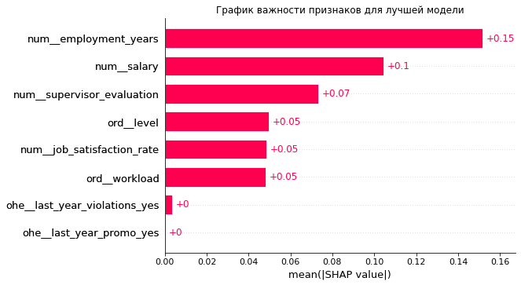

```python
X_train_e = pipe_final_2.named_steps['preprocessor'].fit_transform(X_train_2)
explainer = shap.Explainer(randomized_search_2.best_estimator_.named_steps['models'], X_train_e)
X_test_e = pipe_final_2.named_steps['preprocessor'].transform(X_test_2)

X_test_e = pd.DataFrame(X_test_e, columns = pipe_final_2.named_steps['preprocessor'].get_feature_names_out())
shap_values = explainer(X_test_e)
plt.title('График важности признаков для лучшей модели')
shap.plots.bar(shap_values[:, :, 1], max_display=15)
```

## Задача №2. Выводы

Лучшая модель для решения задачи классификации - DecisionTreeClassifier с параметрами max_depth=31, min_samples_leaf=8, min_samples_split=38, random_state=42.

# Общий вывод

**Задачи проекта** - построить модель, которая сможет предсказать уровень удовлетворённости сотрудника на основе данных заказчика; построить модель, которая сможет на основе данных заказчика предсказать то, что сотрудник уволится из компании.

**Этапы работы:**

- Загрузка данных
- Предобработка данных
- Исследовательский анализ данных
- Подготовка данных в пайплайне
- Обучение моделей

По итогу всех этапов работы, были предложены две модели:

- для задачи регрессии: DecisionTreeRegressor
- для задачи классификации: DecisionTreeClassifier

**Предложения для бизнеса, исходя из получившихся результатов**

Одни из самых важных признаков при предсказании уволнения сотрудника из компании, на которые стоит обратить внимание работодателю - длительность работы в компании (в годах) и ежемесячная зарплата сотрудника. Сотрудники ожидают повышения по должности, заработной платы спустя пару лет работы в компании, если этого не происходит, многие сотрудники переходят в другие конкурентные компании, предлагающие лучшие условия.

Исходя из этого, можно предложить компаниям пересматривать сотрудников младшего уровня по занимаемой должности и длительности работы в компании не более двух лет. Те, которые успешно себя показали в работе, стоит повышать в заработной плате и в перспективе по уровню занимаемой должности. Также стоит учитывать и сотрудников, которые проработали длительный срок в компании, но повышения в заработной плате и по уровню должности за последние пару лет не получали. Стоит отслеживать это, ведь если не повышать таких сотрудников, есть риск для компании, что начнут уходить важные сотрудники. Если это учитывать, тогда уровень внезапных увольнений должен снизиться.